# From Geography to Development: Does Economic Structure Mediate the Latitude–Income Association?

Author

Zekun Song

Published

April 26, 2026

## Introduction

The latitude–income gradient appears to be a pattern in development economics: countries near the equator tend to be poorer, while those farther away tend to be richer. Gallup and Sachs (1999) offered a direct explanation for this pattern. The argument was the tropical disease burden, depressed agricultural yields, and restricted trade access together suppress equatorial development trajectories — leading, in turn, to constrained economic growth.

The hypothesis tested here: geography operates indirectly, first shaping economic structure — the relative weight of agriculture, manufacturing, and services — which in turn influences income levels.

This project uses 2019 cross-country data for 173 nations to test that claim. **Does adding economic structure variables attenuate the latitude–income association, and by how much?** Three sub-questions frame the analysis:

1. Do geographic characteristics (latitude, landlocked status) predict economic structure (agriculture dependence, urbanisation, trade openness)?
2. Does economic structure predict national income (GDP per capita)?
3. Can machine learning classify high-income countries from geographic and structural features — and which variables carry the weight?

## Methods

### Data Sources and Acquisition

Data were obtained from two APIs. **REST Countries** (`restcountries.com/v3.1/all`) provided geographic metadata — latitude, landlocked status, and region — for all sovereign nations. **World Bank Development Indicators** (`api.worldbank.org/v2`) provided five 2019 indicators: GDP per capita, trade share of GDP, urban population share, agriculture share of GDP, and total population.

### Data Cleaning and Wrangling

The sample construction is summarised in Table 1; the final analytic sample contains **173 countries**. Missingness is concentrated in lower-capacity states, so the sample tilts toward countries with stronger statistical systems — the agriculture–income gradient in the results is likely understated relative to the full global distribution. GDP per capita is strongly right-skewed (skewness of approximately 2.1), so it is log-transformed to stabilise variance for OLS; population receives the same treatment.

Table 1: Sample flow from raw API responses to analytic dataset.

[output not shown]

### Feature Engineering

12 features were constructed for the classification task by a specific property or theoretical consideration.

**Distance from the equator** (|latitude|) is the main geographic predictor, and its square is included to allow for a nonlinear latitude–income relationship. **Tropical** (1 if |latitude| < 23.5°) adds a binary climate-zone indicator that complements the continuous latitude measure. **Landlocked** and **region** capture broader geographic and regional constraints. **Log trade share** and **log population** are log-transformed because both variables have heavy right tails. Two interaction terms are also included: agriculture share × landlocked and trade share × urbanisation.

### Variable Selection

Feature selection used LASSO regression with 5-fold cross-validation predicting log GDP per capita. All 12 candidate features were standardised ($\mu = 0$, $\sigma = 1$) before fitting. The optimal $\alpha = 0.0043$ (5-fold CV) retained 11 of 12 features. The one zeroed out — linear distance from equator — had its squared counterpart retained, consistent with a non-linear income gradient that steepens at higher latitudes.

### Statistical Analysis

Analysis proceeds in three layers. Pearson correlations and Welch $t$-tests establish bivariate structure. Five nested OLS models (M1–M5) with HC3 heteroskedasticity-robust standard errors then track how the latitude coefficient moves as structure variables are added block by block — HC3 because cross-country income data is heteroskedastic by construction.

The classification task uses a stratified 80/20 split ($n_\text{train} = 138$, $n_\text{test} = 35$) with 5-fold CV for hyperparameter tuning. Three models are compared: Logistic Regression (linear baseline), Random Forest, and XGBoost. The target is binary high-income status — GDP per capita above $12,535. Performance is evaluated on accuracy, F1, and AUC-ROC.

## Results

### Descriptive Statistics

Table 2: Descriptive statistics for the analytic sample (N = 173 countries, 2019).

| Variable | Mean | SD | Min | Median | Max |
| --- | --- | --- | --- | --- | --- |
| Distance from Equator (°) | 27.2 | 17.4 | 0.0 | 25.0 | 72.0 |
| Landlocked (proportion) | 0.2 | 0.4 | 0.0 | 0.0 | 1.0 |
| Agriculture Share (% of GDP) | 9.5 | 9.6 | 0.0 | 5.7 | 40.7 |
| Trade Share (% of GDP) | 90.4 | 58.5 | 22.8 | 77.6 | 382.7 |
| Urbanization (% of population) | 62.1 | 22.3 | 16.1 | 65.0 | 100.0 |
| GDP per Capita (USD) | 17,390 | 22,651 | 449 | 6,719 | 115,798 |
| Log GDP per Capita | 9 | 1 | 6 | 9 | 12 |
| Population | 42,135,174 | 154,608,879 | 17,798 | 9,054,000 | 1,407,745,000 |

37 of 173 countries (21%) are landlocked; 63 of 173 (36%) clear the high-income threshold of $12,535.

### Geography, Economic Structure, and Income

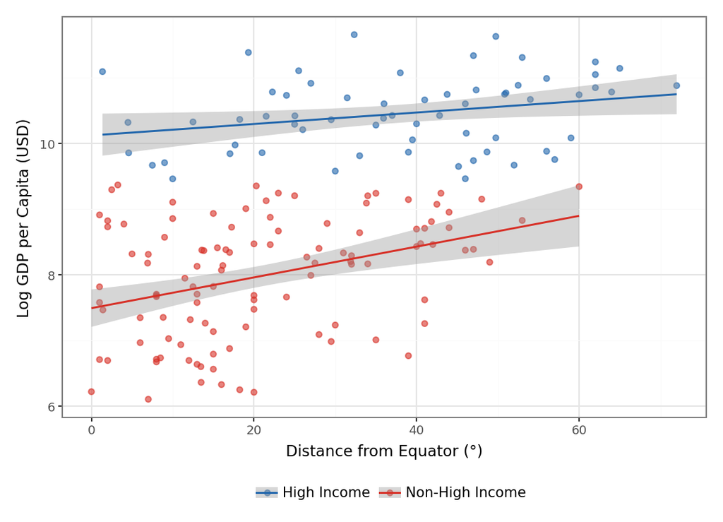

Figure 1: Distance from the equator vs. log GDP per capita across 173 countries (2019), coloured by income group.

Countries farther from the equator tend to have higher log GDP per capita ($r = 0.55$, $p < 0.001$). High-income countries cluster at substantially higher income levels, while non-high-income countries remain concentrated in the lower range.

Table 3: Nested OLS models predicting log GDP per capita.

| Model | Controls | Coef. (Distance from Equator) | Robust SE | R² | Adj. R² |
| --- | --- | --- | --- | --- | --- |
| M1 | — | 0.0449*** | (0.0047) | 0.299 | 0.294 |
| M2 | Landlocked | 0.0481*** | (0.0043) | 0.394 | 0.387 |
| M3 | M2 + Agriculture Share | 0.0262*** | (0.0046) | 0.711 | 0.705 |
| M4 | M3 + Urbanization | 0.0220*** | (0.0045) | 0.750 | 0.744 |
| M5 | M4 + Trade Share | 0.0219*** | (0.0043) | 0.762 | 0.755 |

*** p<0.001 ** p<0.01 * p<0.05 | Latitude coefficient attenuates by 51.2% from M1 to M5.

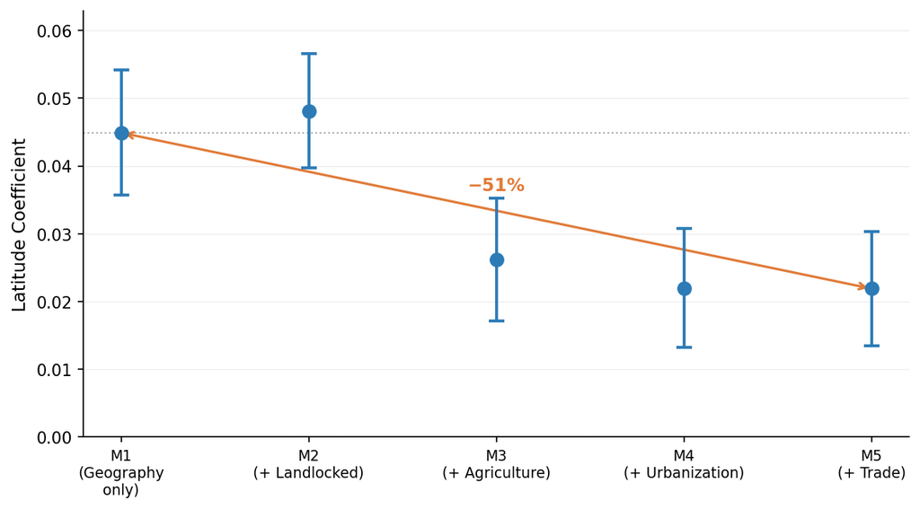

Figure 2: Latitude coefficient and 95% confidence intervals across five nested OLS models. Each model adds one block of controls (x-axis labels); the orange arrow marks total attenuation from M1 to M5.

The latitude coefficient falls from 0.045 in M1 to 0.022 in M5, which falls by 51% as structural variables are added to the model. It decreases siginificantly after agriculture share and urbanization factors are entered. However, the coefficient in M5 (0.022) remains highly significant ($p < 0.001$), means geography is not explained away, but half of its effect operates through economic structure. It recalls the hypothesis.

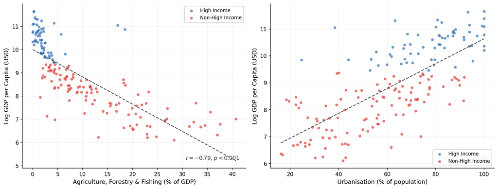

Based on the previous analysis, agriculture share, as the strongest single predictor of income, should be analysis then. The negative association ($r = -0.79$, $p < 0.001$) is showed in this figure. Followed by urbanisation ($r = 0.72$). They capture orthogonal dimensions of the same transformation. Agrarian economies are rural and income-poor; urbanised service economies are dense and income-rich. Agriculture share likely proxies for multiple underlying constraints (productivity, capital intensity, and institutional development), rather than acting as a direct causal driver itself.

### Machine Learning: Classifying High-Income Countries

Table 4: Classification performance on the held-out test set. All models trained with 5-fold cross-validation.

| Model | Accuracy | Precision | Recall | F1 | AUC-ROC |
| --- | --- | --- | --- | --- | --- |
| Logistic Regression | 0.857 | 0.750 | 0.923 | 0.828 | 0.927 |
| Random Forest | 0.886 | 0.846 | 0.846 | 0.846 | 0.958 |
| XGBoost | 0.886 | 0.909 | 0.769 | 0.833 | 0.937 |

All three classifiers perform well. Random Forest leads on both AUC-ROC (0.958) and F1 (0.846); XGBoost follows (AUC = 0.937); Logistic Regression holds close behind (AUC = 0.927). The strong performance across all models suggests that the chosen features capture most of the variance separating high- and low-income countries. The minimal gap between the linear and nonlinear models is somewhat surprising. It implies that global income differences may be captured by relatively simple decision boundaries, with the feature representation doing most of the discriminative work rather than the model architecture.

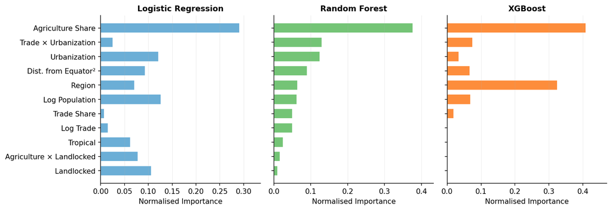

Figure 4: Normalised feature importance for Logistic Regression, Random Forest, and XGBoost. Features are sorted by Random Forest importance; longer bar = greater contribution to that model’s predictions.

[figure not shown]

Figure 5: ROC curves for all three classifiers on the held-out test set. AUC values are shown in the legend; the dashed diagonal is the random-chance baseline.

All three ROC curves lie close to the upper-left corner and well above the random-chance diagonal, indicating strong classification performance. Random Forest achieves the highest AUC (0.958), while XGBoost and Logistic Regression perform similarly (AUC of approximately 0.93). The high AUC across all models suggests that the selected features provide strong discriminative power between high- and non-high-income countries, with only modest gains from increased model complexity.

## Conclusions and Summary

The central question was whether economic structure mediates the latitude–income association. The results are consistent with partial mediation: the latitude coefficient attenuates by 51% once agriculture share and urbanisation enter the model, and structural variables alone recover much of the income divide. But geography does not dissolve, since the coefficient in M5 remains highly significant ($p < 0.001$). This result should not be interpreted causally. The attenuation reflects statistical mediation, not necessarily a structural pathway from geography to income through economic structure; confounding by unmeasured institutional and historical factors cannot be ruled out.

The machine learning results are consistent with this picture. All three classifiers achieve AUC above 0.92, and the narrow gap between Logistic Regression and Random Forest (0.927 vs 0.958). This is itself informative, which means the two income classes occupy a largely linearly separable region in this feature space. The architecture choice contributing relatively little beyond the features themselves.

**Limitations.** The analysis is cross-sectional — 2019 is a single slice, and causal claims are not available. The 39-country attrition concentrated in low-capacity states compresses the lower tail, which means the agriculture–income gradient is likely *stronger* in the full global population than this sample shows. The geographic variables are not very finely specified. Latitude only captures distance from the equator, while mechanisms commonly discussed in the literature — such as tropical disease burden, colonial history, and maritime access — are not included in this analysis. In addition, the test set is relatively small ($n = 35$), so the AUC estimates carry some uncertainty.

**Next Steps.** To better address the causal question, future work could use panel data with country fixed effects and measures of institutional quality. In addition, incorporating variables such as institutional quality (e.g., rule of law, property rights), colonial history, and disease environment could help capture mechanisms that are not reflected by simple geographic measures like latitude. Finally, modelling income as a continuous variable (e.g., log GDP per capita), rather than using a binary high-income classification, could provide a more detailed view of how income varies across countries.

Geography does metter, but not in the way it first appears. Its influence is primarily exerted through the economic structures they shape, thereby creating an invisible divide that has evolved subtly over the course of history. This suggests the existence of deeper institutional and historical forces that cannot be explained by geographical factors alone.